# Almond Yield Anomalies

Author

Jackson Coldiron and Kaitlin Castor

## Introduction

This assignment builds on our almond yield anomaly model by incorporating an economic dimension—profit. Using yield anomalies calculated from climate data, we developed a profit model that estimates annual almond profits based on variable production costs and market prices. We then performed a simple sensitivity analysis to explore how uncertainty in key parameters—specifically cost per acre and price per ton—affects estimated profit across years. This analysis allows us to assess the robustness of almond profitability under different economic scenarios and visualize how sensitive outcomes are to these inputs.

## Data

#### Data Description

The climate dataset (clim.txt) contains daily weather observations including: day: Day of the month; month: Calendar month; year: Calendar year; wy: Water year; tmax_c: Daily maximum temperature (°C); tmin_c: Daily minimum temperature (°C); precip: Daily precipitation (mm)

Other parameters: - location: California - time frame: 1989-2010 - yield model adjusted R**2 = 0.88 - yield model developed from monthly averages aggregated to the state scale from 1980 - 2003 records. This excludes factors such as extreme heat events or spatial variations.

#### Data Processing

```r
# Import libraries
library(tidyverse)
library(here)
library(dplyr)
library(purrr)
library(tibble)
library(knitr)
library(kableExtra)
library(ggpubr)
library(scales)

# Define baseline yield
baseline <- 5

# Import data and function
climate_data_raw <- read.table(here("data", "clim.txt"), header = TRUE, sep = "", quote = "\"")

source(here("R", "almond_yield_function.R"))
source(here("R", "almond_profit_function.R"))
source(here("R", "almond_yield_uncertainty_function.R"))

# Summarize inputs by year for model
yearly_anomalies <- climate_data_raw |>
  group_by(year) |>
  summarise(
    Tn = mean(tmin_c[month == 2], na.rm = TRUE),
    P = sum(precip[month == 1], na.rm = TRUE)) |>
    drop_na() |>
  mutate(yield_anomaly = almond_yield(Tn, P))
```

## Almond Profit

```r
# Bring in the wrapper function
source(here("R", "almond_wrapper_function.R"))

# Apply wrapper function on each year
yearly_profits <- yearly_anomalies |>
  mutate(
    profit = pmap_dbl(
      list(Tn, P),
      function(Tn, P) almond_profit_wrapper(Tn, P)
    )
  )
```

## Sensitivity Analysis

#### Almond Yield Sensitivity

```r
# generate samples for temperature coefficient
nsamples <- 300

Tc <- rnorm(mean = 0.0046, sd = 0.1, n = nsamples)
Pc <- rnorm(mean = 0.0043, sd = 0.1, n = nsamples)

coeff_parms <- cbind.data.frame(Tc, Pc)

# create dataframe with all combinations of parameters

coeff_sensitivity_df <- crossing(
  yearly_anomalies,
  coeff_parms
)

# run the yield anomaly function across the new dataframe
sensitivity_yield <- coeff_sensitivity_df |>
  mutate(
    new_yield = pmap_dbl(
      list(Tc, Pc, Tn, P),
      function(Tc, Pc, Tn, P) almond_yield_uncertainty(
          Tc = Tc,
          Pc = Pc,
          Tn = Tn,
          P = P
        )
    )
  )

sensitivity_yield <- sensitivity_yield[!apply(sensitivity_yield < 0, 1, any), ]
```

```r
# generate samples for both parameters
nsamples <- 300
deviation <- 0.15
base_cost <- 15000

set.seed(42)  # for reproducibility

costs_per_acre <- runif(
  min = base_cost - deviation * base_cost,
  max = base_cost + deviation * base_cost, n = nsamples
)

price_per_ton <- rnorm(mean = 4000, sd = 0.1, n = nsamples)

parms <- cbind.data.frame(costs_per_acre, price_per_ton)

# create dataframe with all combinations of parameters
sensitivity_df <- crossing(
  yearly_anomalies,
  parms
)

# run the profit function across the new dataframe
sensitivity_profit_df <- sensitivity_df |>
  mutate(
    profit = pmap_dbl(
      list(
        price_per_ton = price_per_ton,
        costs_per_acre = costs_per_acre,
        yield_anomaly = yield_anomaly
      ),
      function(price_per_ton, costs_per_acre, yield_anomaly) {
        almond_profit(
          price_per_ton = price_per_ton,
          costs_per_acre = costs_per_acre,
          baseline_yield = 1.25,
          yield_anomaly = yield_anomaly
        )
      }
    )
  )
```

#### Figure 1: Overall Variation of Yield Anomaly

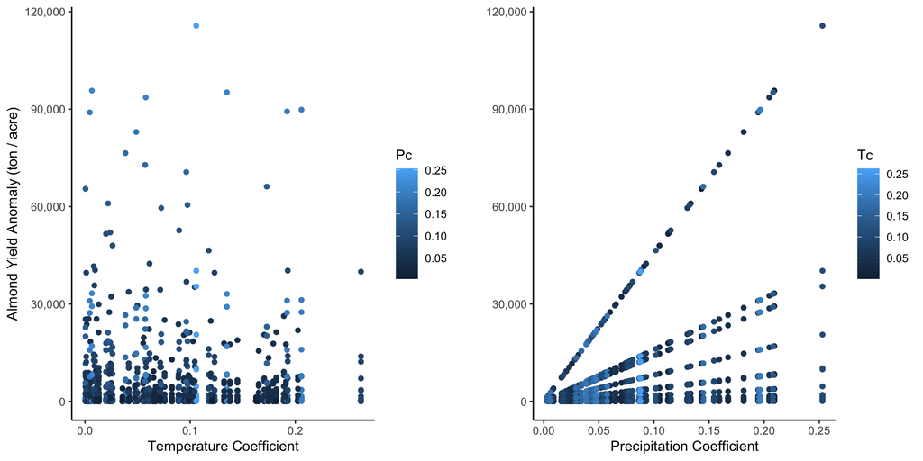

Figure 1: **Almond Yield Anomaly with Uncertainty in Climate Sensitivity Parameters.** The left panel shows how variation in the temperature coefficient (Tc) affects yield anomaly, with colors indicating corresponding precipitation coefficient (Pc) values. The right panel reverses this, showing how yield anomaly varies with the precipitation coefficient (Pc), colored by temperature coefficient (Tc). Together, these plots illustrate how uncertainty in model parameters propagates into yield estimates, and highlight the interaction between temperature and precipitation sensitivity in almond yield response. Negative yields were removed from the dataset.

```r
# create graph with both uncertainties
a <- ggplot(data = sensitivity_yield, aes(Tc, new_yield, col = Pc)) +
  geom_point() +
  labs(
    x = "Temperature Coefficient",
    y = "Almond Yield Anomaly (ton / acre)"
  ) +
  scale_y_continuous(labels = label_comma()) +
  theme_classic()

# create graph switching visualization of uncertainties
b <- ggplot(data = sensitivity_yield, aes(Pc, new_yield, col = Tc)) +
  geom_point() +
  labs(
    x = "Precipitation Coefficient",
    y = ""
  ) +
  scale_y_continuous(labels = label_comma()) +
  theme_classic()

#combine graphs
sensitivity_yield_plot <- ggarrange(a, b)
sensitivity_yield_plot
```

#### Figure 2: Comparison of parameters sensitivity on profit

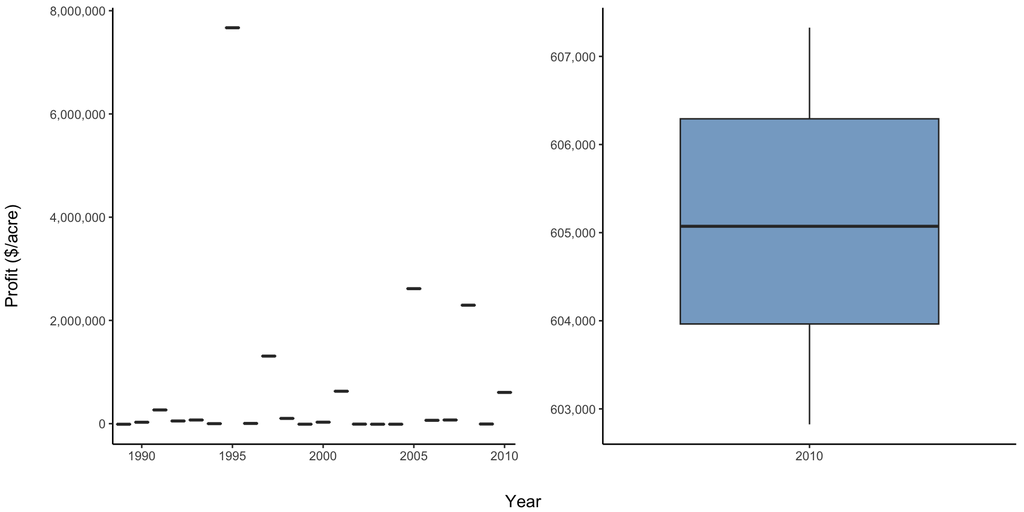

Figure 2: **Almond profits Variation with Uncertainty in Price and Cost**. The graph on the left shows the variation in profit for each year, with uncertainty in price per ton and cost per acre. Because of the large variety in profit across years and major outliers in 1995, 2005 and 2008 the individual box plots for each year, however, are difficult to make out. So, the graph on the right shows just the variation in profit for 2010.

```r
sensitivity_profit_lastyear <- sensitivity_profit_df |>
  filter(year == 2010)

year_levels <- levels(factor(sensitivity_profit_df$year))
every_fifth_year <- year_levels[as.numeric(year_levels) %% 5 == 0]

profit_time_box <- ggplot(sensitivity_profit_df, aes(x = factor(year), y = profit)) +
  geom_boxplot(fill = "#4682B4", alpha = 0.7, outlier.alpha = 0.2) +
  labs(x = "", y = "") +
  scale_y_continuous(labels = label_comma()) +
  scale_x_discrete(breaks = every_fifth_year) +
  theme_classic()

profit_time_lastyear <- ggplot(sensitivity_profit_lastyear, aes(x = factor(year), y = profit)) +
  labs(x = "", y = "") +
  geom_boxplot(fill = "#4682B4", alpha = 0.7, outlier.alpha = 0.2) +
   scale_y_continuous(position = "left") +
  scale_y_continuous(labels = label_comma()) +
  theme_classic()

library(ggpubr)
combined_box <- ggarrange(profit_time_box, profit_time_lastyear)

annotate_figure(
  combined_box,
  left = text_grob("Profit ($/acre)", rot = 90, size = 12),
  bottom = text_grob("Year", size = 12)
)
```

## Discussion

We ran two different models – almond yield uncertainty and almond profit – to understand how sensitive our almond yield is when faced with a range of different uncertainties.

Our almond yield model investigated how uncertainty in temperature and precipitation coefficients affect almond yield anomaly for all years together. Our graphs reveal the precipitation coefficient has a more positive correlation, while the temperature coefficient is more randomly distributed. The different precipitation linear trends observed can be due to the time frame, however additional data exploration is necessary. The overall general trend observed is larger precipitation coefficients combined with smaller temperature coefficients produce larger almond yield anomalies.